# Wheat Yield Data from 2025 Greenhouse Study

Renee Davis

2026-02-03

[GitHub repository](https://github.com/reneeadeledavis/biobead/tree/main/2025greenhouse)

# 1 Methods

## 1.1 Sample Collection

For the number of grain heads, empty grainheads were not recorded. That is, if a plant had 3 grain heads and 1 was empty, it was recorded and analyzed as 2.

# 2 Results

## 2.1 Grains

### 2.1.1 Number of Grain Heads

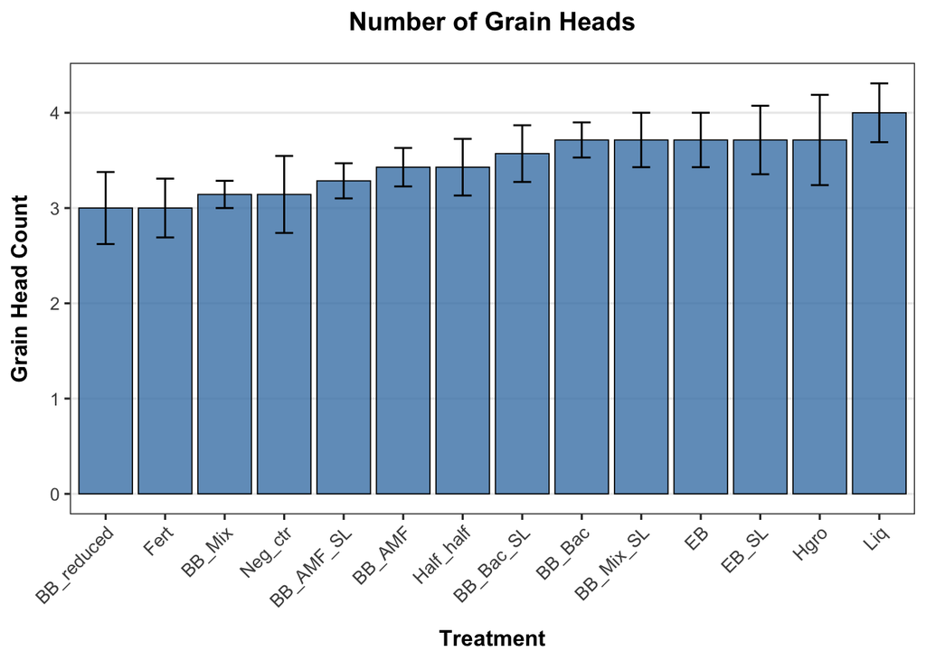

### 2.1.2 Grain Head Weight

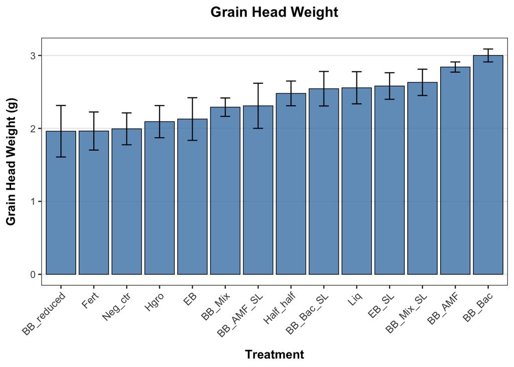

### 2.1.3 Grain Weight

Grain head weight represents the total biomass of the spike, while individual grain weight refers to the mass of individual developed kernels.

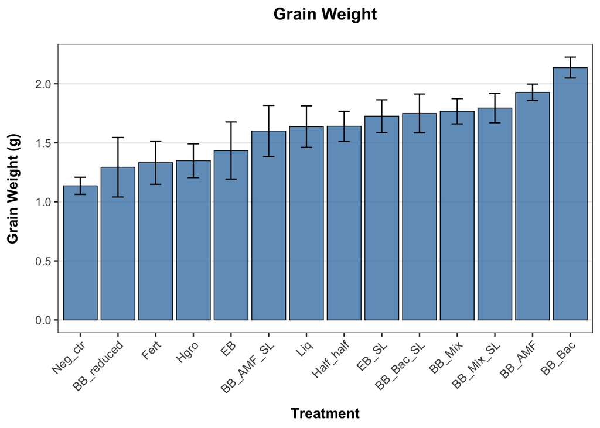

```r
anova_grainweight <- aov(GrainWeight_g ~ Treatment, data = wheatyield_2025)
summary(anova_grainweight)
```

```
##             Df Sum Sq Mean Sq F value  Pr(>F)
## Treatment   13  6.816  0.5243   2.904 0.00163 **
## Residuals   84 15.165  0.1805
## ---
## Signif. codes:  0 '***' 0.001 '**' 0.01 '*' 0.05 '.' 0.1 ' ' 1
```

BioBead with bacteria only is a top performing treatment with respect to grain weight. With AMF only, grain weight decreases slightly. With AMF and bacteria, grain weight decreases. A One Way ANOVA reveals statistically significant differences between treatments. A post-hoc Tukey HSD test identifies the following pairs as having statistically significant effects with respect to grain weight:

- Neg_ctr-BB_AMF (diff -0.791428571, p = 0.0458673)
- BB_reduced-BB_Bac (diff -0.844285714, p = 0.0231325)
- Fert-BB_Bac (diff = -0.805714286, p = 0.0383145)
- Hgro-BB_Bac (diff = -0.788571429, p = 0.0475256)
- Neg_ctr-BB_Bac (diff = -1.001428571, 0.0023191)

## 2.2 Harvest Index

Harvest Index (HI) is an agricultural metric representing the efficiency of a crop in partitioning biomass into the harvestable economic yield. In the case of wheat, the economic yield is the grain weight. So this number represents grain weight divided by above ground straw and grain head weight.

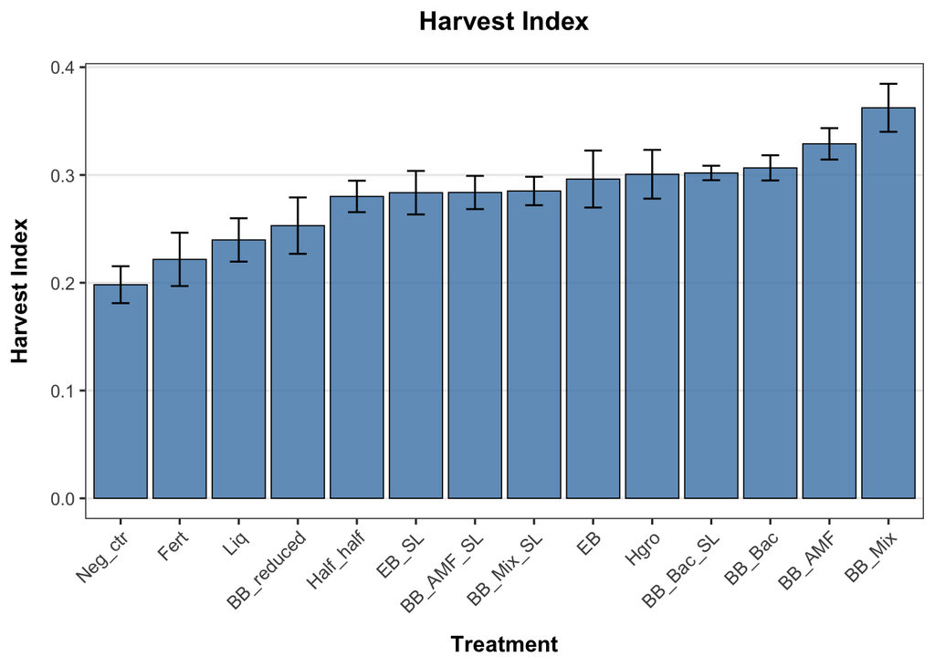

```r
anova_harvest_index <- aov(Harvest_Index ~ Treatment, data = wheatyield_2025)
summary(anova_harvest_index)
```

```
##             Df Sum Sq  Mean Sq F value   Pr(>F)
## Treatment   13 0.1645 0.012654   4.933 2.37e-06 ***
## Residuals   84 0.2155 0.002565
## ---
## Signif. codes:  0 '***' 0.001 '**' 0.01 '*' 0.05 '.' 0.1 ' ' 1
```

The BioBead with bacteria and AMF is the best performing treatment with HI. A One Way ANOVA reveals statistically significant differences between treatments. A post-hoc Tukey HSD test identifies the following pairs as having statistically significant effects with respect to grain weight:

- Fert-BB_AMF (diff = -0.1072086581, p = 0.0107640)
- Neg_ctr-BB_AMF (diff = -0.1306838019, p = 0.0004953)
- Neg_ctr-BB_Bac (diff = -0.1083843070, p = 0.0093394)
- Neg_ctr-BB_Bac_SL (diff = -0.1036589771, p = 0.0163740)
- BB_reduced-BB_Mix (diff = -0.1092990847, p = 0.0083542)
- Fert-BB_Mix (diff = -0.1406258417, p = 0.0001183)
- Liq-BB_Mix (diff = -0.1225708403, p = 0.0015140)
- Neg_ctr-BB_Mix (diff = -0.1641009854, p = 0.0000032)
- Neg_ctr-EB (diff = -0.0980049533, p = 0.0309877)
- Neg_ctr-Hgro (diff = -0.1024527209, p = 0.0188215)

Most of the significant differences are between negative controls and other treatment groups. However, fertilizer treatments generally performed poorly compared to the biologicals, especially BioBead.

## 2.3 Root:Shoot Ratio

The Root:Shoot ratio (R:S) is the ratio of dry root biomass to dry shoot biomass. It is as an indicator of plant health, nutrient efficiency, and resource allocation. Higher ratios (more roots) typically indicate stress (particularly drought/nutrient deficiency), while lower ratios (more shoots/above ground parts) suggest favorable, nutrient-rich environments.

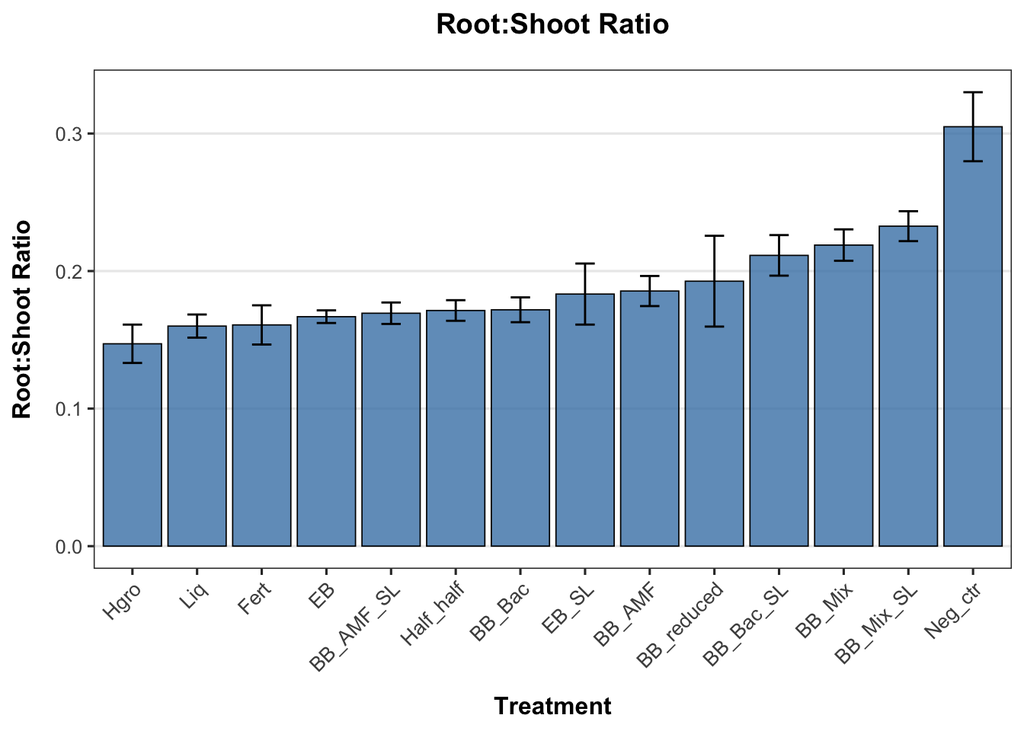

```r
anova_root_shoot <- aov(Root_Shoot ~ Treatment, data = wheatyield_2025)
summary(anova_root_shoot)
```

```
##             Df Sum Sq  Mean Sq F value   Pr(>F)
## Treatment   13 0.1512 0.011633   6.675 1.39e-08 ***
## Residuals   84 0.1464 0.001743
## ---
## Signif. codes:  0 '***' 0.001 '**' 0.01 '*' 0.05 '.' 0.1 ' ' 1
```

A One Way ANOVA reveals statistically significant differences between treatments. A post-hoc Tukey HSD test identifies that nearly every group has a statistically significant difference in R:S compared to negative control.

# 3 Discussion

## 3.1 Next steps

1. Plot residual histograms and QQ plots to verify normality with ANOVA error.